# RNASeqWorkflow : RNA-Seq workflow for one independent variable analysis

Author: Kuan-Hao Chao (ntueeb05howard@gmail.com)

Last update: 03 September, 2018

#### Abstract

An RNA-Seq workflow for one independent variable analysis

# Contents

!!! Coding style ~ `code`, `file suffix`, `value`, `parameter` *‘file directory’* ‘operating system’ Normal software name

# 1 Introduction

RNA-Seq(RNA sequencing) uses next-generation sequencing(NGS) to provide transcriptome profiling. It has changed our thought about how complex eukaryotic transcriptomes are(Mortazavi et al. 2008).([RNA-Seq Blog](https://www.rna-seqblog.com/introduction-to-rna-sequencing-and-analysis/)). This technique is widely used to look at alternative gene spliced transcripts, post-transcriptional modification, SNPs over time, differences in gene expression in different groups or treatment etc.([wiki](https://en.wikipedia.org/wiki/RNA-Seq)). Among them, differential expressed gene(DEG) analysis is the most common downstream analysis.

`RNASeqWorkflow` provides an easier and R-based approach for running end-to-end two-group RNA-Seq analysis from quality assessment, trimming to downstream differential gene analysis, functional, pathway analysis. Some important features include automated workflow, comprehensive visulization reports, organized, extendable file structure and supporting background process in each step etc.

The following are main tools that are used in this package: ‘[HISAT2](https://ccb.jhu.edu/software/hisat2/index.shtml)’ for reads alignment; ‘[StringTie](https://ccb.jhu.edu/software/stringtie/)’ for alignments assembly and transcripts quantification; ‘[systemPipeR](https://bioconductor.org/packages/release/bioc/html/systemPipeR.html)’ package for quality assessment; ‘ShortRead’ package for quality trimming; ‘[ballgown](https://bioconductor.org/packages/release/bioc/html/ballgown.html)’ package, ‘TPM & Student’s t-test’, ‘[DESeq2](https://bioconductor.org/packages/release/bioc/html/DESeq2.html)’ package and ‘[edgeR](https://bioconductor.org/packages/release/bioc/html/edgeR.html)’ package for finding potential DEGs; ‘[clusterProfiler](https://bioconductor.org/packages/release/bioc/html/clusterProfiler.html)’ package for Gene Ontology(GO) functional analysis and Kyoto Encyclopedia of Genes and Genomes(KEGG) pathway analysis.

Functions with `CMD` suffix create an R script and process in background. Functions with no `CMD` suffix process in R shell. After running the above functions, the whole RNA-Seq analysis is done and generated files in each step will be stored in organized file directory. `RNASeqWorkflow` package makes two-group RNA-Seq analysis **more efficient** and **easier** for users.

# 2 System Requirement

Necessary:

1. Operating System: ‘Linux’ and ‘macOS’ are supported in `RNASeqWorkflow` package. ‘Windows’ is not supported. (Because `StringTie` and `Hisat2` are not available for ‘Windows’)
2. C Environment for `SAMtools`: `Samtools` source code will be installed and compiled.
3. `HISAT2` indexex: Users are strongly advised to provide *‘indices/’* directory in *‘inputfiles/’*. If not provided, `HISAT2` requires at least 160 GB of RAM and several hours to index the entire human genome.

Recommended:

1. Python: Python2 or Python3.
2. `2to3`: If the Python version in the system is 3, then this command will be used. Generally, `2to3` is available if Python3 is available. (Python and `2to3` is used for creating raw reads count for [DESeq2](https://bioconductor.org/packages/release/bioc/html/DESeq2.html) and [edgeR](https://bioconductor.org/packages/release/bioc/html/edgeR.html). If these commands are not available, DESeq2 and edgeR analysis will be skipped.)

# 3 “RNASeqWorkFlowParam” S4 Object Creation

This is the **pre-step** of RNA-Seq workflow in this package. Before starting RNA-Seq analysis, you have to run the constructor function `RNASeqWorkFlowParam()` and create `RNASeqWorkFlowParam` S4 object first. This object, which stores checked parameters, will be used as input parameter in the following analysis function.

## 3.1 `RNASeqWorkFlowParam` Slots Explanation

There are 11 slots in `RNASeqWorkFlowParam`:

1. `os.type` : The operating system type. Value is `linux` or `osx`. This package only support ‘Linux’ and ‘macOS’ (no ‘Windows’). If other operating system is detected, ERROR will be reported.
2. `python.variable` : Python-related variable. Value is a list of whether Python is available and Python version (`TRUE` or `FALSE`, `2` or `3`).
3. `python.2to3` : Availability of `2to3` command. Value is `TRUE` or `FALSE`.
4. `path.prefix` : Path prefix of *‘gene_data/’*, *‘RNASeq_bin/’*, *‘RNASeq_results/’*, *‘Rscript/’* and *‘Rscript_out/’* directories. It is recommended to create a new directory with out any file inside and all the following RNA-Seq results will be installed in it.

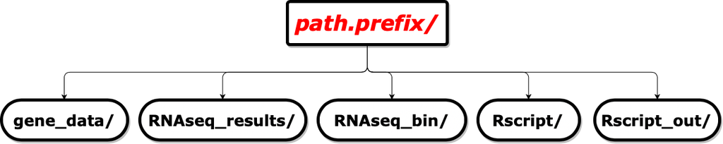

5. `input.path.prefix` : Path prefix of *‘input_files/’* directory. User have to prepare an *‘input_file/’* directory with the following rules:
   - **`genome.name`.fa** : reference genome in FASTA file formation.
   - **`genome.name`.gtf** : gene annotation in GTF file formation.
   - **raw_fastq.gz/**: directory storing `FASTQ` files.
     - Support paired-end reads files only.
     - Names of paired-end `FASTQ` files : ’`sample.pattern`_1.fastq.gz’ and ’`sample.pattern`_2.fastq.gz’. `sample.pattern` must be distinct for each sample.
   - **phenodata.csv** : information about RNA-Seq experiment design.
     - First column : Distinct ids for each sample. Value of each sample of this column must match `sample.pattern` in `FASTQ` files in *‘raw_fastq.gz/’*. Column names must be **ids**.
     - Second column : independent variable for the RNA-Seq experiment. Value of each sample of this column can only be parameter `case.group` and `control.group`. Column name is parameter `independent.variable`.
   - **indices/** : directory storing `HT2` indices files for HISAT2 alignment tool.
     - This directory is **optional**. `HT2` indices files corresponding to target reference genome can be installed at [HISAT2 official website](https://ccb.jhu.edu/software/hisat2/index.shtml). Providing `HT2` files can accelerate the subsequent steps. It is highly advised to install `HT2` files.
     - If `HT2` index files are not provided, *‘input_files/indices/’* directory should be deleted.

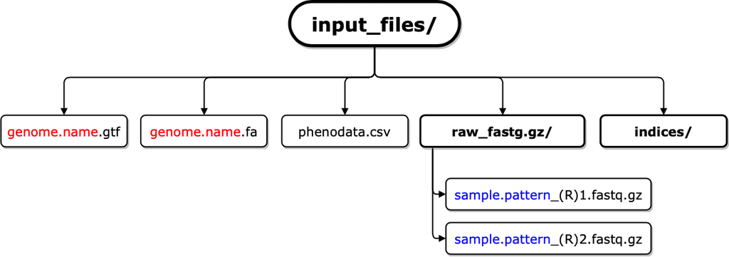

6. `genome.name` : Variable of genome name defined in this RNA-Seq workflow (ex. ‘`genome.name`.fa’, ‘`genome.name`.gtf’)
7. `sample.pattern` : Regular expression of paired-end fastq.gz files under *‘input_files/raw_fastq.gz/’*. **IMPORTANT!!** Expression shouldn’t have `_[1,2].fastq.gz` in end.
8. `independent.variable`: Independent variable for the biological experiment design of two-group RNA-Seq workflow.
9. `case.group` : Group name of the case group.
10. `control.group` : Group name of the control group.
11. `indices.optional` : logical value whether *‘input_files/indices/’* is exit. Value is `TRUE` or `FALSE`

## 3.2 `RNASeqWorkFlowParam` Constructor Checking Steps

1. Create a new directory for RNA-Seq analysis. It is highly recommended to create a new directory without any files inside. The parameter `path.prefix` of `RNASeqWorkFlowParam()` constructor should be the absolute path of this new directory. All the RNA-Seq related files that generated in the following steps will be stored inside of this directory.
2. Create valid *‘input_files/’* directory. You should create a file directory named *‘input_files/’* with neccessary files inside. It should follow the rules metioned above.
3. Run constructor of `RNASeqWorkFlowParam` S4 object. This constructor will check the validity of input parameters before creating S4 objects.
   - Operating system
   - Python version
   - 2to3 command
   - Structure, contents and rules of *‘inputfiles/’*
   - Validity of input parameters

## 3.3 Example

```r
# exp <- RNASeqWorkFlowParam(path.prefix = NA, input.path.prefix = NA,
# genome.name = NA, sample.pattern = NA, independent.variable = NA,
# control.group = NA, experiment.group = NA)
```

In this example, `RNASeqWorkFlowParam` S4 object is store in `exp` for subsequent RNA-Seq analysis steps. Any ERROR occured in checking steps will terminate the program.

# 4 Environment Set up

This is the **first necessary step** of RNA-Seq workflow in this package. To set up the environment, run `RNASeqEnvironmentSet_CMD()` to execute process in background or run `RNASeqEnvironmentSet()` to execute process in R shell.

## 4.1 Files Set up

1. Create Base Directories. *‘gene_data/’*, *‘RNASeq_bin/’*, *‘RNASeq_results’*, *‘Rscript’* and *‘Rscript_out’* will be created under `path.prefix` directory. Here are the usage of these five main directories:
   - *‘gene_data/’*: Symblic links of *‘input_files/’* and files that are created in each step of RNA-Seq analysis will be stored in this directory.
   - *‘RNASeq_bin/’*: The binaries of necessary tools, HISAT2, SAMtools, StringTie and Gffcompare, are installed in this directory.
   - *‘RNASeq_results’*: The RNA-Seq results, for example, alignment results, quality assessment results, differential analysis results etc., will be stored in this directory.
   - *‘Rscript’*: If your run `XXX_CMD()` function, corresponding R script(`XXX.R`) for certain step will be created in the directory.
   - *‘Rscript_out’*: The corresponding output report for R script(`XXX.Rout`) will be stored in this directory.
2. Symbolic links will be created from files in *‘input_files/’* to `path.prefix` directory.

## 4.2 Necessary Tools Installation

The operating system of your workstation will be detected. If the operating system is other than `Linux` and `macOS`, ERROR will be reported. HISAT2, SAMtools, StringTie and Gffcompare will be installed automatically.

- HISAT2
  - Based on your operating system, `hisat2-2.1.0-Linux_x86_64.zip` or `hisat2-2.1.0-OSX_x86_64.zip` zipped file will be installed.
  - Installed file will be unzipped and all binary files will be copied under *‘RNASeq_bin/’*
- SAMtools
  - `samtools-1.8.tar.bz2` source files will be installed.
  - Installed files will be unzipped and compiled. If there is any ERROR occurred during compilation, program will be stopped. You should check whether the development environment is OK for SAMtools before rerunning `RNASeqEnvironmentSet_CMD` or `RNASeqEnvironmentSet()` to set up the environment again.
  - Maked SAMtools binary will be copied under *‘RNASeq_bin/’*.
- StringTie
  - Based on your operating system, `stringtie-1.3.4d.Linux_x86_64.tar.gz` or `stringtie-1.3.4d.Linux_x86_64` zipped file will be installed.
  - Installed file will be unzipped and all binary files will be copied under *‘RNASeq_bin/’*.
- Gffcompare
  - Based on your operating system, `gffcompare-0.10.4.Linux_x86_64.tar.gz` or `gffcompare-0.10.4.Linux_x86_64.tar.gz` zipped file will be installed.
  - Installed file will be unzipped and all binary files will be copied under *‘RNASeq_bin/’*.

## 4.3 Export Path

*‘RNASeq_bin/’* will be added to R PATH so that these binaries can be found in R environment. In the last step of environment setting, `hisat2 --version`,`stringtie --version`,`gffcompare --version`,`samtools --version` commands will be checked in order to make sure the environment is correctly constructed.

## 4.4 Example

1. Run in background Result will be reported in *‘Rscript_out/Environment_Set.Rout’*. Make sure the environment is successfully set up before running the subsequent steps.

```r
# RNASeqEnvironmentSet_CMD()
```

2. Run in R shell Result will be reported in R shell. Make sure the environment is successfully set up before running the subsequent steps.

```r
# RNASeqEnvironmentSet()
```

# 5 `FASTQ` Files Quality Assessment

This is an **optional step** of RNA-Seq workflow in this package. However, it is strongly recommended to do it before processing reads. To assess the quality of raw reads in `FASTQ` files, run `RNASeqQualityAssessment_CMD()` to execute process in background or run `RNASeqQualityAssessment()` to execute process in R shell.

## 5.1 “systemPipeR” Quality Assessment

In this process, [systemPipeR](http://bioconductor.org/packages/release/bioc/html/systemPipeR.html) package is used for quality assessment. Here are the following steps:

1. Check the number of times that user has run quality assessment process and create the corresponding files *‘RNASeq_results/QA_results/QA_{times}’*.
2. RNA-Seq environment set up. *‘rnaseq/’* directory will be created by [systemPipeR](http://bioconductor.org/packages/release/bioc/html/systemPipeR.html) package.
3. Create *‘data.list.txt’* file.
4. Reading `FASTQ` files and create *‘fastqReport.pdf’* as the report result of quality assessment
5. Remove *‘rnaseq/’* directory.

## 5.2 Example

1. Run in background Result will be reported in *‘Rscriptout/Quality_Assessment.Rout’*. Make sure quality assessment is successfully done before running the subsequent steps.

```r
# RNASeqQualityAssessment_CMD()
```

2. Run in R shell Result will be reported in R shell. Make sure quality assessment is successfully done before running the subsequent steps.

```r
# RNASeqQualityAssessment()
```

# 6 `FASTQ` Files Quality Trimming

This is an **optional step** of RNA-Seq workflow in this package. However, it is strongly recommended to do it if the result of quality assessment is unsatisfied. To trim the raw reads in `FASTQ` files, run `RNASeqQualityTrimming_CMD()` to execute process in background or run `RNASeqQualityTrimming()` to execute process in R shell. After trimming process, it is strongly recommended to redo quality assessment step. Different quality assessment result will be stored in different directories with index of processing order.

## 6.1 “ShortRead” Quality Trimming

In this process, [ShortRead](http://bioconductor.org/packages/release/bioc/html/ShortRead.html) package is used for quality trimming. Followings are trimming steps and method explanation.

1. `FASTQ` files with `sample.pattern` in *‘gene_data/raw_fastq.gz’* will be listed and be check. This trimming function only support paired-end `FASTQ` files.
2. The probability of error per each base pair is calculated by Phred Quality in `FASTQ` files and the cumulative probability of error of each base pair will also be calculated. The threshold cumulative probability `cum.error`, with default value `1`, is used to find the trimming point of paired end files.
3. `reads.length.limit`, with default value 36, determines the minimum base pair length of reads. Length of reads less than `reads.length.limit` will be filtered out.
4. Untrimmed original `FASTQ` files are moved to *‘gene_data/raw_fastq.gz/original_untrimmed_fastq.gz’*, and trimmed reads are written to *‘gene_data/raw_fastq.gz/’*
5. It is strongly recommended to run `RNASeqQualityAssessment_CMD()` or `RNASeqQualityAssessment()` for quality assessment after quality trimming.

## 6.2 Example

```r
# RNASeqQualityAssessment_CMD()
```

2. Run in R shell Result will be reported in R shell. Make sure quality assessment is successfully done before running the subsequent steps.

```r
# RNASeqQualityAssessment()
```

# 7 Reads Process (Alignment, Assembly, Gffcompare, Quantification)

This is a **second necessary step** of RNA-Seq workflow in this package. Programs installed in environment setting step, HISAT2, SAMtools, StringTie and Gffcompare, will be executed. To process raw reads `FASTQ` files, run `RNASeqRawReadProcess_CMD()` to execute process in background or run `RNASeqRawReadProcess()` to execute process in R shell. For more details about commands that executed during each reads processing step, please check the reported *‘RNASeq_results/COMMAND.txt’*.

## 7.1 HISAT2 Index

In pre-step(`RNASeqWorkFlowParam` creation step), *‘indices/’* directory is checked and the whether `HT2` indices files are provided is known. If not provided, following commands will be executed:

- Input: `genome.name`.gtf, `genome.name`.fa
- Output: `genome.name`.ss, `genome.name`.exon, `genome.name`_tran.{number}.ht2
1. `extract_splice_sites.py`, `extract_exons.py` execution
   - These two commands are executed to extract splice-site and exon information from gene annotation file.
2. `hisat2-build` index creation
   - This command build HISAT2 indices files with *`genome.name`.ss* and *`genome.name`.exon* created in the previous step. Be aware that index building step requires a larger amount of memory and longer time than steps, and it might not be possible to run on some personal workstations. It is highly recommended to check the availibility of `HT2` indices files at [HISAT2 official website](https://ccb.jhu.edu/software/hisat2/index.shtml) for your target reference genome beforehands. Install `HT2` indices files will greatly shorten the analysis time.
3. Write *‘RNASeq_results/COMMAND.txt’*
   - Shell command that run in this step will be documented into *‘RNASeq_results/COMMAND.txt’*.

## 7.3 SAMtools `SAM` to `BAM`

- Input: `sample.pattern`.sam
- Output: `sample.pattern`.bam
1. `samtools` command is executed. Output `SAM` files from HISAT2 will be converted to `BAM` files.
   - `BAM` files are stored in *‘gene_data/raw_sam/’*.
2. Write *‘RNASeq_results/COMMAND.txt’*
   - Shell command that run in this step will be documented into *‘RNASeq_results/COMMAND.txt’*.

## 7.4 StringTie Assembly

- Input: `genome.name`.gtf, `sample.pattern`.bam
- Output: `sample.pattern`.gtf
1. `stringtie` command is executed.
   - Assembler of RNA-Seq alignments into potential transcripts.
   - Output assembled `GTF` files which are from each `FASTQ` files are stored in *‘gene_data/raw_gtf/’*
2. Write *‘RNASeq_results/COMMAND.txt’*
   - Shell command that run in this step will be documented into *‘RNASeq_results/COMMAND.txt’*.

## 7.5 StringTie Merge `GTF`

- Input: `sample.pattern`.gtf
- Output: stringtiemerged.gtf, mergelist.txt
1. Creating mergelist.txt
   - *gene_data/merged/mergelist.txt* is created for the merging step.
2. `stringtie` command is executed.
   - Transcript merger merges each *`sample.pattern`.gtf* into *stringtiemerged.gtf*
   - Output files are all stored in *‘gene_data/merged/’*
3. Write *‘RNASeq_results/COMMAND.txt’*
   - Shell command that run in this step will be documented into *‘RNASeq_results/COMMAND.txt’*.

## 7.6 Gffcompare

- Input: `genome.name`.gtf, stringtie_merged.gtf
- Output: merged.annotated.gtf, merged.loci, merged.stats, merged.stringtie_merged.gtf.refmap, merged.stringtie_merged.gtf.tmap, merged.tracking
1. `gffcompare` command is executed.
   - The comparison result of merged `GTF` file and reference annotation file is reported under *‘merged/’* directory.
2. Write *‘RNASeq_results/COMMAND.txt’*
   - Shell command that run in this step will be documented into *‘RNASeq_results/COMMAND.txt’*.

## 7.7 StringTie Creates Ballgown Input Directories

- Input: stringtie_merged.gtf
- Output: ballgown/, gene_abundance/
1. `stringtie` command is executed.
   - StringTie will create the input directory for ballgown package for the following differential analysis. Ballgown-related files will be stored by each sample name in *‘gene_data/ballgown/’*.
   - StringTie will store gene-related information in `TSV` file by each sample name in *‘gene_data/gene_abundance/’*.
2. Write *‘RNASeq_results/COMMAND.txt’*
   - Shell command that run in this step will be documented into *‘RNASeq_results/COMMAND.txt’*.

## 7.8 Raw Reads Count Table Creation

Whether this step is executed depends on the availability of Python on your workstation.

- Input: samplelst.txt
- Output: gene_count_matrix.csv, transcript_count_matrix.csv
1. Reads count table converter Python script is downloaded as `prepDE.py`
2. Python checking
   - If Python is not available, this step is skipped.
   - If Python2 is available, `prepDE.py` is executed.
   - If Python3 is available, `2to3` command will be checked.(Usally, if Python3 is installed, `2to3` command will be installed too.)
   - If Python3 is available but `2to3` command is unavailable, raw reads count generation step will be skipped.
   - If Python3 and `2to3` command is available, `prepDE.py` is converted to file that can be executed by Python2 and be executed.
3. raw reads count creation
   - Raw reads count is created and the results are stored in *‘gene_data/reads_count_matrix/’*
4. Write *‘RNASeq_results/COMMAND.txt’*
   - Shell command that run in this step will be documented into *‘RNASeq_results/COMMAND.txt’*.

## 7.9 Example

1. Run in background Result will be reported in *‘Rscriptout/Raw_Read_Process.Rout’*. Make sure raw read process is successfully done before running the subsequent steps.

```r
# RNASeqRawReadProcess_CMD()
```

2. Run in R shell Result will be reported in R shell. Make sure raw read process is successfully done before running the subsequent steps.

```r
# RNASeqRawReadProcess()
```

# 8 Differential Gene Expression Analysis

This is the **third necessary step** of RNA-Seq workflow in this package. To do differential gene expression analysis, run `RNASeqDifferentialAnalysis_CMD()` to execute process in background or run `RNASeqDifferentialAnalysis()` to execute process in R shell. In `RNASeqWorkflow` package, we provide four ways to do differential analysis: ballgown, TPM & Student t-test, DESeq2 and edgeR.

Before running this step, the raw reads count *‘gene_data/reads_count_matrix/gene_count_matrix.csv’*, which is generated in the previous step, will be trimmed. The reads sum of each row equals `0` will be filtered out. And due to the reason that genes have different isoform, the reads of different gene ID in StringTie that maps to same gene name will be considered as same gene and be added and merged into one row. Trimmed gene raw reads count will be the input of DESeq2 and edgeR.

After finding differential expressed genes, some general plots will be drawn in each differential analysis tool. The following are the plots: * Pre differential analysis sample profile related plot: * Frequency Plot: The frequency of normalized values will be drawn by using [rafalib](https://cran.r-project.org/web/packages/rafalib/index.html) package. X axis is `log2(normalized_values)`; Y axis is `Frequency`. * Box Plot & Violin Plot: The distribution normalized values of each sample will be drawn by [ggplot2](https://ggplot2.tidyverse.org) package. X axis is `Samples`; Y axis is `Log2(normalized_values+1)`. * PCA Plot : The principal components analysis(PCA) will be calculated on normalized values by [FactoMineR](http://factominer.free.fr) and [factoextra](https://cran.r-project.org/web/packages/factoextra/index.html) packages. One dimension bar plot ([factoextra](https://cran.r-project.org/web/packages/factoextra/index.html)), two PCA plots ([factoextra](https://cran.r-project.org/web/packages/factoextra/index.html) and [graphics](https://stat.ethz.ch/R-manual/R-devel/library/graphics/html/00Index.html)) will be created. * Correlation Plot : The correlation of each pair of samples will be calculated. One correlation dot plot ([corrplot](https://cran.r-project.org/web/packages/corrplot/vignettes/corrplot-intro.html)), one correlation bar plot ([PerformanceAnalytics](https://cran.r-project.org/web/packages/PerformanceAnalytics/PerformanceAnalytics.pdf)) and one correlation heat plot ([ggplot2](https://ggplot2.tidyverse.org)) will be created.

- Differential analysis related plot
  - Volcano Plot : The upregulated and downregulated genes will colored with red and green. X axis is `log2(Fold Change)`; Y axis is `log2(p value)`. It is drawn by [graphics](https://stat.ethz.ch/R-manual/R-devel/library/graphics/html/00Index.html) package.
  - PCA Plot : The principal components analysis(PCA) of selected differential expressed genes will be calculated on their normalized values by [FactoMineR](http://factominer.free.fr) and [factoextra](https://cran.r-project.org/web/packages/factoextra/index.html) packages. One dimension bar plot ([factoextra](https://cran.r-project.org/web/packages/factoextra/index.html)), two PCA plots ([factoextra](https://cran.r-project.org/web/packages/factoextra/index.html) and [graphics](https://stat.ethz.ch/R-manual/R-devel/library/graphics/html/00Index.html)) will be created.
  - Heatmap Plot : Heatmap will be ploted by using [pheatmap](https://cran.r-project.org/web/packages/pheatmap/pheatmap.pdf) package.

## 8.1 “ballgown” Analysis

[Ballgown](https://www.bioconductor.org/packages/release/bioc/html/ballgown.html) is designed to facilitate flexible differential expression analysis of RNA-Seq data ([ballgown github](https://github.com/alyssafrazee/ballgown)). The default statistical model is a parametric F-test comparing nested linear models. Normalized row count in [ballgown](https://www.bioconductor.org/packages/release/bioc/html/ballgown.html) is represented as FPKM values. The following are [ballgown](https://www.bioconductor.org/packages/release/bioc/html/ballgown.html) analysis steps:

- Input: *‘gene_data/ballgown/’*
- Output: *‘RNASeq_results/ballgown_analysis/’*
1. `ballgown` object is created and written in *‘RNASeqresults/ballgownanalysis/ballgownRobject/ballgown.rda’*.
2. Row of extracted statistic results from created ballgown object with `pval` equals `0` or `qval` equals `0` will be filterd out. Log 2 fold change value will be calculated as column name `log2FC`.
3. The row sum of sample FPKM values equal ‘0’ will be filter out. According to the *‘gene_data/phenodata.csv’* file, normalized count will be seperated into case and control group with column name *`sample.pattern.FPKM`*.
4. A report `CSV` file combined with normalized FPKM count, average of case group, control group and statistic results will be stored as *‘RNASeq_results/ballgown_analysis/ballgown_normalized_result.csv’*.
5. Differential expressed gene result *‘RNASeq_results/ballgown_analysis/ballgown_normalized_DE_result.csv’* is reported. Default selecting threshold is **`pval < 0.05` and `log2FC > 1 | log2FC < 1`**
6. Visualization. The plots mentioned above and the following plot will be drawn.
   - Differential analysis related plot
     - MA Plot : The plot visualizes the differences between case and control by transforming the data onto X axis `log2FC` and Y axis `log2(FPKM.mean)`. It is drawn by [ggplot2](https://ggplot2.tidyverse.org) package.

## 8.5 Example

1. Run in background Result will be reported in *‘Rscriptout/Differential_Analysis.Rout’*. Make sure differential expression analysis is successfully finished before running subsequent steps.

```r
# RNASeqDifferentialAnalysis_CMD()
```

2. Run in R shell Result will be reported in R shell. Make sure differential expression analysis is successfully finished before running subsequent steps.

```r
# RNASeqDifferentialAnalysis()
```